# Mixed effects models in R

**Sean Trott**  
*November 18, 2019*

# High-level goals

This tutorial is intended as an accompaniment to my 11/18/2019 workshop, “Mixed effects models in R”. The goals of the lecture-portion of that workshop (and thus this tutorial) are to address the following questions:

1. Why build mixed effects models?
2. How can you decide what to model as a **fixed** vs. a **random** effect? And more broadly, which random effects do you need to account for?
3. What should your data look like? How do you actually run a model in `lme4`?
4. How do you interpret and report the results?

The examples given will likely focus on *linear* models in particular (where the critical contrast is between OLS regression and linear mixed models), but where possible I will describe extensions to other models[^1].

In writing this tutorial, I drew heavily from a number of existing tutorials and resources. I strongly endorse all of them:

- [Bates et al (2014): Fitting linear mixed-effects models using lme4](https://arxiv.org/pdf/1406.5823.pdf)
- [Winter (2013): Linear models and linear mixed effects models in R with linguistic applications](https://arxiv.org/ftp/arxiv/papers/1308/1308.5499.pdf)
- [Barr et al (2013): Random effects structure for confirmatory hypothesis testing: Keep it maximal](https://www.ncbi.nlm.nih.gov/pmc/articles/PMC3881361/)
- [Bates et al (2015): Parsimonious mixed models](https://arxiv.org/pdf/1506.04967.pdf)

# Load libraries

First, logistics. We’ll be working with two main libraries: `library(tidyverse)` and `library(lme4)`. If you don’t have them installed already, use `install.packages("tidyverse")` and `install.packages("lme4")` to install them.

# Brief (and likely unnecessary) introduction

The point of building statistical models is to quantify relationships between two or more variables. For example, how **correlated** are `A` and `B`?

This quantification is done in the service of some theoretical goal, e.g., to adjudicate between competing hypotheses. Thus, researchers often want to know some second-order information about this relationship, such as how **unexpected** it is. In the traditional approach of [null hypothesis significance testing](https://en.wikipedia.org/wiki/Statistical_hypothesis_testing), this amounts to asking about the probability of your data under the null hypothesis, e.g., `p(d|h)`: a *p-value*[^2].

Another popular approach is to use some kind of **goodness of fit** measure, i.e., how successfully does your model fit the data? Using a [model selection](https://en.wikipedia.org/wiki/Model_selection) procedure, various models can be fit to the data and selected on the basis of their explanatory power (using some heuristic to enforce model parsimony). This is especially useful when examining complex, multivariate relationships because it allows researchers to ask whether their variable of interest explains independent sources of variance from other variables, i.e., how much they improve a model without that variable. The goal of a model selection procedure is to settle on the simplest model that best explains your data.

## Note on causal inference

It’s important to note that statistical models alone don’t grant you **causal inference**. Of course, it is well-known that [correlation does not imply causation](https://en.wikipedia.org/wiki/Correlation_does_not_imply_causation), but it is surprisingly easy to forget this when modeling the relationship between two or more variables, especially when one has a strong **prior** on the causal directionality of this relationship (e.g., that **smoking causes cancer** rather than **cancer causes smoking**).

Statistical models are essentially agnostic to your prior beliefs about causal relationships. Causal inference thus comes from external factors, such as the design of an experiment that randomly manipulates some variable of interest. The use of [randomized controlled trials (RCTs)](https://en.wikipedia.org/wiki/Randomized_controlled_trial) is thought to permit causal inference by way of counterfactual reasoning: because your subjects all had an equal chance of assignment to each of your experimental conditions, and because your conditions only manipulate one variable of interest, you can infer that any differences observed across your conditions are *due to* the manipulation[^3].

# Why used mixed models?

All statistical methods have a set of assumptions baked into them.

One assumption shared by many statistical methods is that each data point is **independent**, i.e., not dependent on or related to any other observation. For example, if you flip a coin, the probability of getting heads should be independent of other flips; in our theoretical model of coin-flipping, we assume that the generative process underlying a given coin flip is independent of the process underlying other coin flips. Similarly, a procedure like OLS regression assumes that each data point was generated by an independent causal process, and therefore, that your data points are all independent.

This is a useful assumption, and in many cases, is perfectly acceptable.

## When the independence assumption is met

When is independence fair to assume? Broadly speaking: your data points are independent if you’ve ruled out the possibility of some nested causal process generating multiple observations in your dataset. This causal process could be a *person* (e.g., the same participant contributing multiple data points), an *item* (e.g., the same item being answered by different participants, where the item itself isn’t your variable of interest), or in certain contexts, even an *institution* (e.g., multiple participants coming from the same school).

**Example 1**: You want to know whether a new pharmaceutical drug increases self-reported happiness. You randomly assign people to take the drug vs. some placebo, and 1 month later, each participant answers a single question (e.g., “How happy are you (1-7)?”). You then use a t-test or OLS regression to compare the distribution of people assigned to the treatment group to the distribution of people assigned to the placebo group. Here, each participant contributed exactly 1 data point, so it’s pretty reasonable to assume each data point is independent.

**Example 2**: You want to know whether people respond different to one kind of metaphor than another. You assign 200 subjects to 1 of two conditions (`A` vs. `B`). Each subject is exposed to exactly 1 of 2 possible items (`A` vs. `B`). In other words, it’s a between-subjects design with only one item. Again, it seems like these are independent observations; the only similarities across observations are exactly the ones you’re interested in (i.e., experimental condition). Thus, you can run a t-test or OLS regression to ask whether responses are different in the `A` vs. `B` condition.

Examples 1-2 seem to meet the independence assumption[^4].

Anyway, when the independence assumption is met, you can analyze it with something like OLS regression; an example using simulated data is shown below. (Note that for the remainder of the tutorial, analyses will be discussed from the perspective of regression; [this](https://lindeloev.github.io/tests-as-linear/) is a useful resource explaining how many common statistical tests actually reduce to linear regression.)

### Simulation and analysis

#### Simulate and visualize the data

Let’s simulate some data. Just to make it obvious, we’ll start out by simulating two normal distributions with different means and identical standard deviations. As depicted below, these groups will have some overlap but still look pretty different.

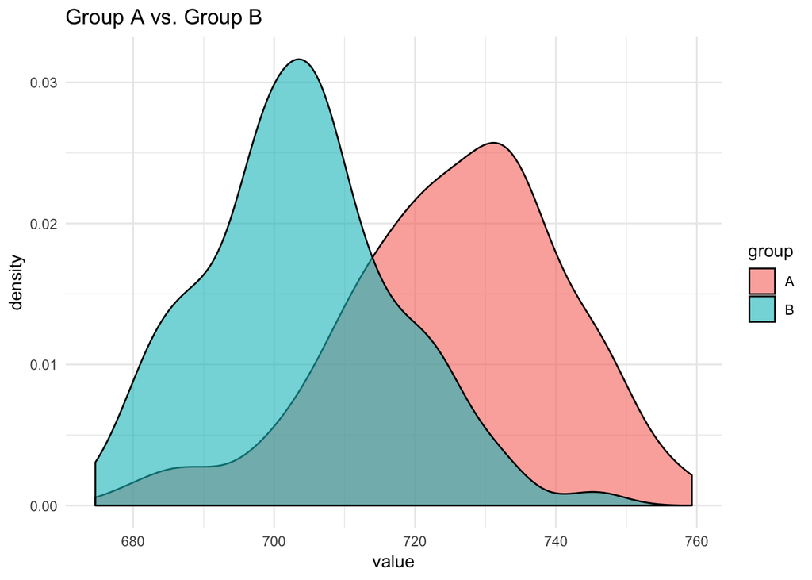

```r
### Set random seed
set.seed(42)

### Illustration of two different distributions, A vs. B

A = rnorm(100, mean = 725, sd = 15)
B = rnorm(100, mean = 705, sd = 15)

df = data.frame(A = A,
           B = B) %>%
  gather() %>%
  mutate(group = key)

df %>%
  ggplot(aes(x = value,
             fill = group)) +
  geom_density(alpha = .6) +
  labs(title = "Group A vs. Group B") +
  theme_minimal()
```

#### Detour: explanation of OLS

These two groups look pretty different. One way to quantify their difference is to use [ordinary least squares regression](https://en.wikipedia.org/wiki/Ordinary_least_squares), predicting `value` from `group`, e.g., `value ~ group`.

Recall that the goal of OLS is to **learn a set of coefficients for your predictors that minimize the difference between the predicted values of your model and the observed values**. Abstractly, the formula for linear regression looks like this:

$Y \sim X + \epsilon$

Where $Y$ represents our dependent variable, $X$ represents our predictor (or **fixed effect**), and $\epsilon$ represents an error term. Here, “error” broadly encompasses everything that the model doesn’t “know” about where variance in $Y$ might come from (i.e., variance not correlated with variance in $X$); the tighter the relationship between $X$ and $Y$, the smaller this error term will be.

With OLS, we want to estimate coefficients for our regressors. These coefficients are sometimes called **slopes**, because they refer to the slope of the line that best fits $X$ to $Y$. They’re usually represented by the $\beta$ term in formal representations:

$Y \sim X\beta + \epsilon$

With continuous data, $\beta$ means: with every 1-unit increase in $X$, change $Y$ by $\beta$. Categorical data (e.g., two discrete conditions) is actually pretty similar, but instead of continuous changes in $X$, we’re interested in the slope of the line between one level of the factor (e.g., `A`) and the other level (e.g., `B`); thus, discrete changes in $X$ correspond to some predicted change in $Y$ by $\beta$.

#### Model the data

Back to our simulated data. We can apply these principles to modeling the potential differences between our two groups.

Let’s run a linear model:

```r
simple_model = lm(data = df,
           value ~ group)

summary(simple_model)
```

```
##
## Call:
## lm(formula = value ~ group, data = df)
##
## Residuals:
##     Min      1Q  Median      3Q     Max
## -45.384  -8.757   0.775   9.320  41.841
##
## Coefficients:
##             Estimate Std. Error t value Pr(>|t|)
## (Intercept)  725.488      1.463  495.97   <2e-16 ***
## groupB       -21.800      2.069  -10.54   <2e-16 ***
## ---
## Signif. codes:  0 '***' 0.001 '**' 0.01 '*' 0.05 '.' 0.1 ' ' 1
##
## Residual standard error: 14.63 on 198 degrees of freedom
## Multiple R-squared:  0.3593, Adjusted R-squared:  0.3561
## F-statistic: 111.1 on 1 and 198 DF,  p-value: < 2.2e-16
```

There’s a lot of results here, but for our purposes, we’re primarily interested in the coefficient on our fixed effect, `group`. By default, R uses reference coding, which means that one level of a categorical variable is chosen as the **intercept**; thus, if `A` is chosen as our intercept, then the intercept value will correspond to the mean of that distribution. We can verify this ourselves:

```r
simple_model$coefficients["(Intercept)"]
```

```
## (Intercept)
##    725.4877
```

```r
mean(A)
```

```
## [1] 725.4877
```

If we look below the intercept value, we see the coefficient for our fixed effect, `group`. Here, it should say something like `groupB`. The coefficient should thus be interpreted *in contrast* (or *in reference*) to the intercept value.

```r
coef_value = simple_model$coefficients["groupB"]
coef_value
```

```
##    groupB
## -21.79998
```

In other words: according to our model, observations in group `B` are on average -21.8 units lower than observations in group `A`. Again, we can verify this ourselves by calculating the difference between the means of these groups:

```r
round(mean(B) - mean(A), 2)
```

```
## [1] -21.8
```

## When independence is not met

# Example with repeated measures

## Load and summarize dataset

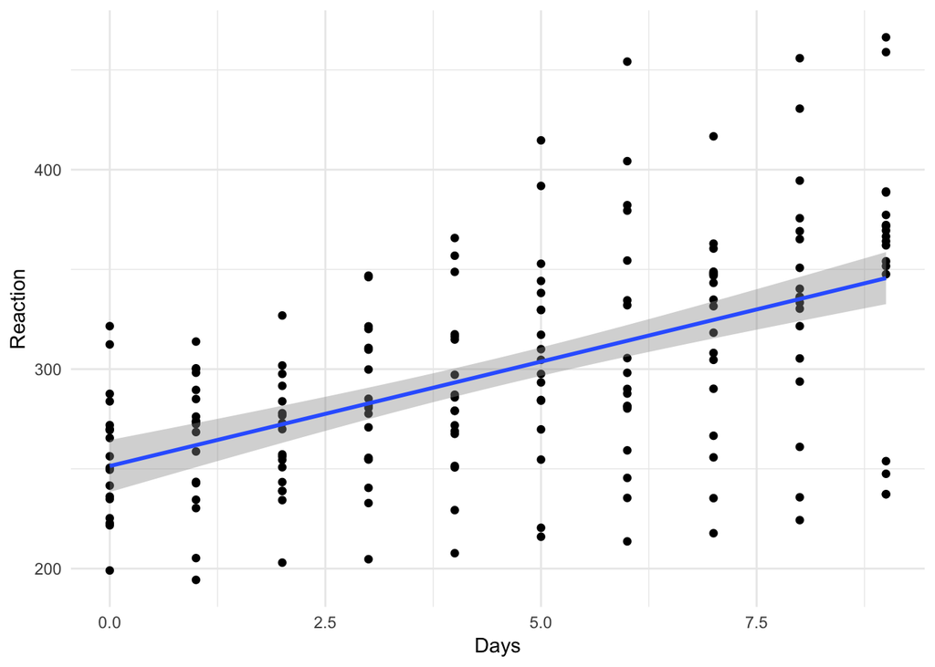

```r
sleepstudy %>%
  ggplot(aes(x = Days,
             y = Reaction)) +
  geom_point() +
  geom_smooth(method = "lm") +
  theme_minimal()
```

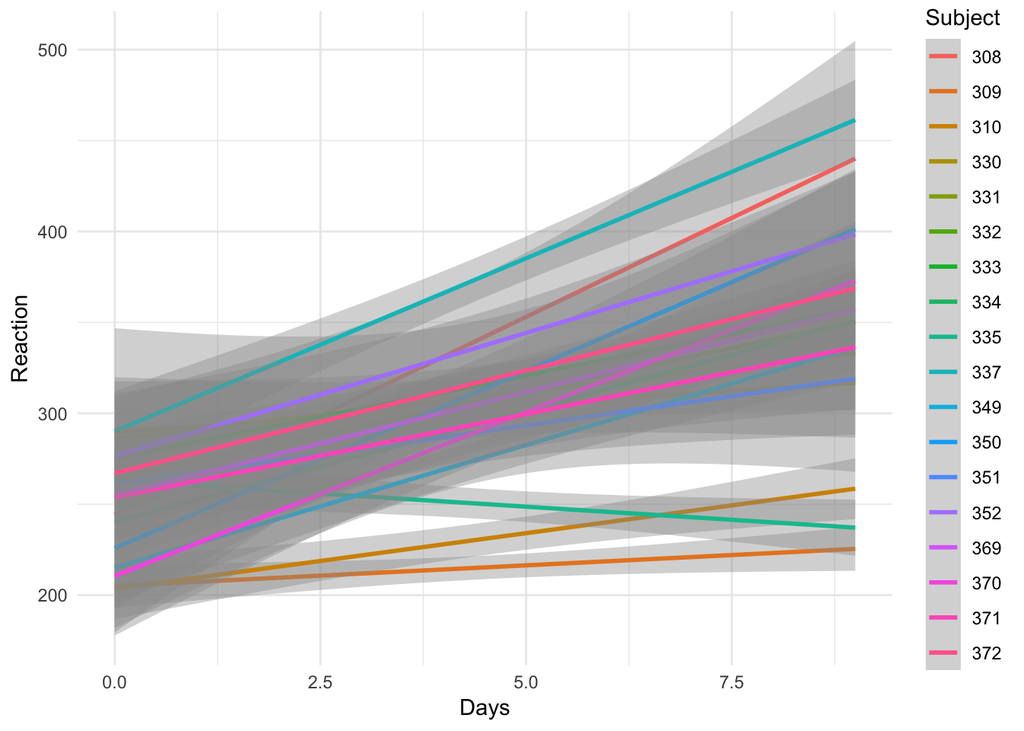

```r
sleepstudy %>%
  ggplot(aes(x = Days,
             y = Reaction,
             color = Subject)) +
  # geom_point() +
  geom_smooth(method = "lm") +
  theme_minimal()
```

[^1]: Note that `glmer` is the command to fit a generalized linear mixed model, which allows you to fit gaussian models and also binomial, poisson, and more.
[^2]: This is *not* the probability that the null hypothesis is true, nor is it the probability that your effect will replicate.
[^3]: Though the **validity** of this manipulation as a stand-in for your theoretical construct is another question.
[^4]: Of course, one can imagine circumstances under which we’d be worried that this assumption is violated; e.g., maybe the participants assigned to take the drug happened to come from one part of the country, and the participants assigned to take the placebo happened to come from another. If your assignment procedure is truly randomized, this shouldn’t be the case, but nonetheless: it’s always important to watch out for signs of non-independence.